# NYC-YellowTaxi-Data-Exploration slides

## Exploring NYC Yellow Taxi Data

Data Source: http://www.nyc.gov/html/tlc/html/about/trip_record_data.shtml

First, let's read in the data and the necessary libraries. The bulk of our data will in be tripdata.dec17 and tripdata.zones will be used as a dictionary (look up table) to map specific zones for Drop-Off and Pick-Ups.

```r
library(dplyr)
library(ggplot2)
library(gridExtra)

tripdata.dec17 <- read.csv("yellow_tripdata_2017-12.csv")
tripdata.zones <- read.csv("taxi_zone_lookup.csv")
```

Now map the zones accordingly. For e.g. PULocationID = 1 means that the Taxi Meter was engaged at Newark Aiport in the EWC Borough

```r
tripdata.dec17.v1 <- tripdata.dec17
tripdata.dec17.v1$PUZone <- tripdata.zones[match(tripdata.dec17.v1$PULocationID, tripdata.zones$LocationID), 3]
tripdata.dec17.v1$DOZone <- tripdata.zones[match(tripdata.dec17.v1$DOLocationID, tripdata.zones$LocationID), 3]
tripdata.dec17.v1$PUBorough <- tripdata.zones[match(tripdata.dec17.v1$PUZone, tripdata.zones$Zone), 2]
tripdata.dec17.v1$DOBorough <- tripdata.zones[match(tripdata.dec17.v1$DOZone, tripdata.zones$Zone), 2]
```

Now, let's see which Pick-Up Zones and Drop-Off Zones are the most popular in NYC.

```r
PUZone.count <- tripdata.dec17.v1 %>% count(PUZone) %>% arrange(desc(n))
DOZone.count <- tripdata.dec17.v1 %>% count(DOZone) %>% arrange(desc(n))

head(PUZone.count)
head(DOZone.count)
```

| PUZone | n |
| --- | --- |
| Upper East Side South | 401291 |
| Upper East Side North | 366256 |
| Midtown Center | 352423 |
| Penn Station/Madison Sq West | 327255 |
| Times Sq/Theatre District | 323303 |
| Midtown East | 316354 |

| DOZone | n |
| --- | --- |
| Upper East Side North | 375686 |
| Midtown Center | 357070 |
| Upper East Side South | 346310 |
| Times Sq/Theatre District | 299999 |
| Midtown East | 289778 |
| Murray Hill | 288985 |

Upper East Side and Midtown are seemingly the most popular taxi zones. Not surprising as said zones are in **Manhattan!** Now, let's verify if Manhattan is indeed the most popular borough in NYC.

```r
PUBorough.count <- tripdata.dec17.v1 %>% count(PUBorough) %>% arrange(desc(n))
DOBorough.count <- tripdata.dec17.v1 %>% count(DOBorough) %>% arrange(desc(n))

PUBorough.count
DOBorough.count
```

| PUBorough | n |
| --- | --- |
| Manhattan | 8659791 |
| Queens | 543373 |
| Unknown | 177569 |
| Brooklyn | 118919 |
| Bronx | 7758 |
| EWR | 732 |
| Staten Island | 134 |

| DOBorough | n |
| --- | --- |
| Manhattan | 8386498 |
| Queens | 459252 |
| Brooklyn | 405758 |
| Unknown | 179912 |
| Bronx | 55788 |
| EWR | 18946 |
| Staten Island | 2122 |

Not even close. An estimated **8 million trips** in the month of December alone!

What about the average fare (total amount paid including tips) by boroughs?

```r
aggregate(tripdata.dec17.v1$total_amount, list(tripdata.dec17.v1$PUBorough), mean)
```

| Group.1 | x |
| --- | --- |
| Bronx | 16.91217 |
| Brooklyn | 16.76778 |
| EWR | 94.70505 |
| Manhattan | 14.38715 |
| Queens | 43.87853 |
| Staten Island | 46.46112 |
| Unknown | 18.41551 |

Average fare amounts to a mere **14 dollars** per trip in Manhattan. I'm assuming this is because people take short trips inside the city. Whereas, if a passenger is picked up from Staten Island, Queens, or EWR, the average trip distance is most likely further away.

But, I'm really curious about the **94 dollars** average total fare amount if a passenger gets picked up in EWR (Newark Airport). Why is it so high?

```r
EWR.tripdata <- dplyr::filter(tripdata.dec17.v1, PUBorough == "EWR")

summary(EWR.tripdata$total_amount)
```

```
   Min. 1st Qu.  Median    Mean 3rd Qu.    Max.
 -76.60   80.30  100.30   94.71  115.93  750.30
```

Looking at the summary data it seems like there are a number of outliers and misentered data. Let's clean that up a bit.

RemoveOutliers function will take the taxi dataframe, substitute negative fares with its median, and calculates its lower bound and upper bound using the IQR Rule.

```r
RemoveOutliers <- function(data) {
    data$total_amount[data$total_amount <= 0] <- median(data$total_amount)
    lowerbound <- quantile(data$total_amount, 0.25) - 1.5*IQR(data$total_amount)
    upperbound <- quantile(data$total_amount, 0.75) + 1.5*IQR(data$total_amount)
    data <- dplyr::filter(data, total_amount >= lowerbound, total_amount <= upperbound)
    return(data)
}

EWR.tripdata <- RemoveOutliers(EWR.tripdata)
summary(EWR.tripdata$total_amount)
```

```
   Min. 1st Qu.  Median    Mean 3rd Qu.    Max.
  27.04   90.30  102.30  101.92  116.22  166.55
```

The mean and median is much closer to each other now (but, their values have increased!). Let's visualize its histogram.

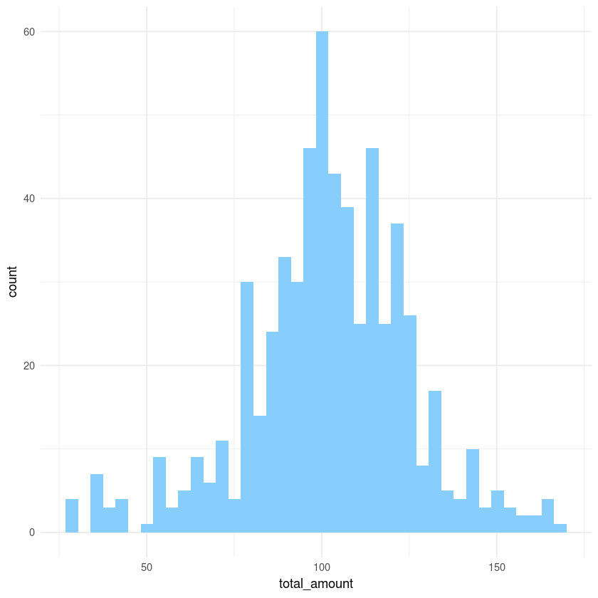

```r
options(warn=-1)
histogram.EWR <- ggplot(aes(total_amount), data = EWR.tripdata) +
    geom_histogram(bins = 40, fill = "skyblue1") +
    theme_minimal()
print(histogram.EWR)
```

How about the other boroughs?

```r
Bronx.tripdata <- RemoveOutliers(dplyr::filter(tripdata.dec17.v1, PUBorough == "Bronx"))
Brooklyn.tripdata <- RemoveOutliers(dplyr::filter(tripdata.dec17.v1, PUBorough == "Brooklyn"))
Manhattan.tripdata <- RemoveOutliers(dplyr::filter(tripdata.dec17.v1, PUBorough == "Manhattan"))
Queens.tripdata <- RemoveOutliers(dplyr::filter(tripdata.dec17.v1, PUBorough == "Queens"))
Staten.tripdata <- RemoveOutliers(dplyr::filter(tripdata.dec17.v1, PUBorough == "Staten Island"))
AllBoroughs.tripdata <- do.call("rbind", list(Bronx.tripdata, Brooklyn.tripdata, Manhattan.tripdata, Queens.tripdata, Staten.tripdata, EWR.tripdata))
```

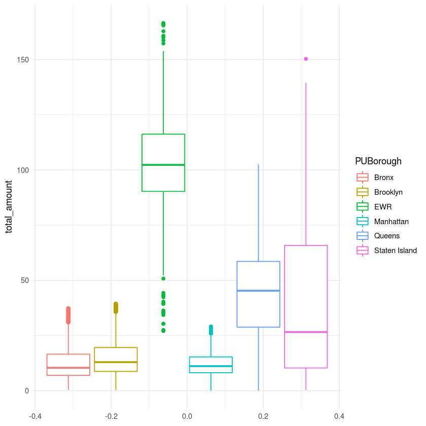

```r
nyc.boroughs.box <- ggplot() +
    geom_boxplot(data = AllBoroughs.tripdata, aes(y = total_amount, color = PUBorough)) +
    theme_minimal()
print(nyc.boroughs.box)
```

Bronx and Brooklyn are relatively similar, and Staten Island seems to possess a wider dispersion.

### Let's calculate a 95% confidence interval to estimate the true population mean of each borough's average total fare amount.

I will employ the t-statistic since I am working with the sample standard deviation.

```r
ConfidenceInterval.TDist <- function(data, bname) {
    data.n <- length(data$total_amount)
    data.a <- mean(data$total_amount)
    data.d <- sd(data$total_amount)
    error <- qt(0.975, df = data.n-1)*data.d/sqrt(data.n)
    conf.interval <- data.frame(borough.name = bname, lower.bound = data.a - error, mean = data.a, upper.bound = data.a + error)
    return(conf.interval)
}

EWR.CI <- ConfidenceInterval.TDist(EWR.tripdata, "EWR")
Bronx.CI <- ConfidenceInterval.TDist(Bronx.tripdata, "Bronx")
Brooklyn.CI <- ConfidenceInterval.TDist(Brooklyn.tripdata, "Brooklyn")
Manhattan.CI <- ConfidenceInterval.TDist(Manhattan.tripdata, "Manhattan")
Queens.CI <- ConfidenceInterval.TDist(Queens.tripdata, "Queens")
Staten.CI <- ConfidenceInterval.TDist(Staten.tripdata, "Staten Island")
```

```r
trip.CI <- do.call("rbind", list(EWR.CI, Bronx.CI, Brooklyn.CI, Manhattan.CI, Queens.CI, Staten.CI))
trip.CI
```

| borough.name | lower.bound | mean | upper.bound |
| --- | --- | --- | --- |
| EWR | 100.04110 | 101.92163 | 103.80216 |
| Bronx | 12.51397 | 12.69494 | 12.87591 |
| Brooklyn | 14.87907 | 14.92559 | 14.97211 |
| Manhattan | 12.27076 | 12.27445 | 12.27815 |
| Queens | 43.09810 | 43.15246 | 43.20681 |
| Staten Island | 34.68011 | 41.23465 | 47.78919 |

There is a 95% probability that the true mean for EWR's average total fare amount is between 100 and 103 dollars assuming that the original random variable is normally distributed, and the samples are independent.

```r
tripdata.dec17.v2 <- tripdata.dec17
tripdata.dec17.v2$PUService <- tripdata.zones[match(tripdata.dec17.v1$PULocationID, tripdata.zones$LocationID), 4]
tripdata.dec17.v2$DOService <- tripdata.zones[match(tripdata.dec17.v1$DOLocationID, tripdata.zones$LocationID), 4]
```

### Another interesting test we can conduct is to further split the data into two different zones (Boro zones and Yellow zones) and conduct **an unpaired two-samples t-test** to compare their means.

Boro taxis are taxis in NYC that are allowed to pick up passengers in outer boroughs(the Bronx, Brooklyn, Queens, and Staten Island) and in Manhattan above East 96th and West 110th Streets.

Yellow taxis however can pick up passengers from anywhere.

```r
BORO.tripdata <- RemoveOutliers(dplyr::filter(tripdata.dec17.v2, PUService == "Boro Zone"))
YELLOW.tripdata <- RemoveOutliers(dplyr::filter(tripdata.dec17.v2, PUService == "Yellow Zone"))

summary(BORO.tripdata$total_amount)
summary(YELLOW.tripdata$total_amount)
```

```
   Min. 1st Qu.  Median    Mean 3rd Qu.    Max.
   0.01    7.30   10.80   12.77   16.55   34.55
```

```
   Min. 1st Qu.  Median    Mean 3rd Qu.    Max.
   0.01    8.19   11.15   12.30   15.30   28.94
```

Let's visualize a density area graph for the two zones

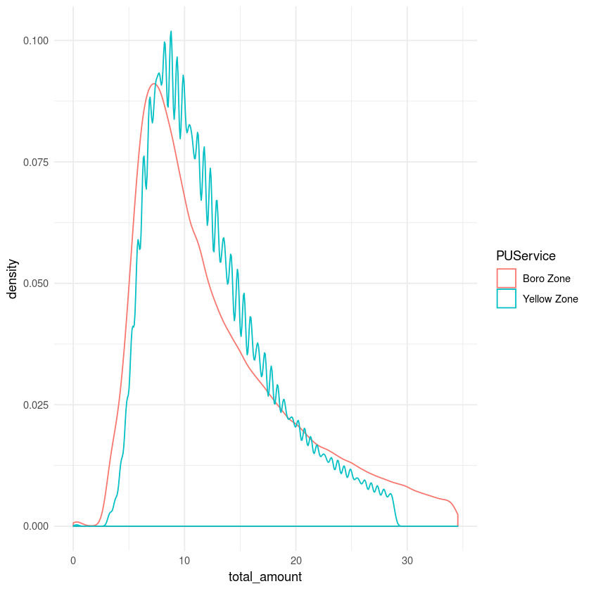

```r
service.tripdata <- do.call("rbind", list(BORO.tripdata, YELLOW.tripdata))
nyc.service.density <- ggplot() +
    geom_density(data = service.tripdata, aes(x = total_amount, color = PUService)) +
    theme_minimal()
print(nyc.service.density)
```

What about the mean and standard deviation for the two zones?

```r
group_by(service.tripdata, PUService) %>%
  summarise(
    count = n(),
    mean = mean(total_amount, na.rm = TRUE),
    sd = sd(total_amount, na.rm = TRUE)
  )
```

| PUService | count | mean | sd |
| --- | --- | --- | --- |
| Boro Zone | 423738 | 12.76625 | 6.958979 |
| Yellow Zone | 7900184 | 12.29660 | 5.364402 |

#### Preliminary test to check independent t-test assumptions

Assumption 1: Are the two samples independents? **YES**

Assumption 3. Do the two populations have the same variances? **We'll need to conduct an F-test**

```r
s1 <- sample_n(BORO.tripdata, 100)
s2 <- sample_n(YELLOW.tripdata, 100)

res.ftest <- var.test(s1$total_amount, s2$total_amount)
res.ftest
```

```
	F test to compare two variances

data:  s1$total_amount and s2$total_amount
F = 1.5295, num df = 99, denom df = 99, p-value = 0.03565
alternative hypothesis: true ratio of variances is not equal to 1
95 percent confidence interval:
 1.029110 2.273191
sample estimates:
ratio of variances
          1.529498
```

The p-value of F-test is p = 0.03565. It’s less than the significance level alpha = 0.05.

Thus, there is a significant difference between the variances of the two sets of data. Therefore, we cannot use the classic t-test which assume equality of the two variances.

Instead, we will use Welch's Two Sample t-test.

```r
t.test(s1$total_amount, s2$total_amount, var.equal = FALSE)
```

```
	Welch Two Sample t-test

data:  s1$total_amount and s2$total_amount
t = 1.3734, df = 189.69, p-value = 0.1713
alternative hypothesis: true difference in means is not equal to 0
95 percent confidence interval:
 -0.5461211  3.0497211
sample estimates:
mean of x mean of y
  13.3468   12.0950
```

The p-value of the test is 0.1713, which is greater than the significance level alpha = 0.05. Hence, we **cannot reject the null hypothesis** and conclude that Yellow zones’ average total fare is not significantly different from Boro zones’ average total fare with a p-value = 0.1713.